# Array and Lists

1. Introduction
2. Array
3. Lists

```csharp
using System;
// using System.Collections.Generic;
// using System.Linq;
// using System.Text;
// using System.Threading.Tasks;
```

## Arrays

We we going to cover the different types of arrays.

1. Single dimensional arrays which we covered
2. MultiDimensional Arrays, which is divided into Rectangular and Jaggered Array.

Lets look at implementing a matrix using a 2d array

```
var matrix = new int[3,5];
```

So this array, we have 3 rows and 5 columns. And we can initialize it as follows, using object initialization syntax:

```
var matrix = new int[3,5]{
{3,4,5,6,7},
{1,3,6,7,10},
{11,12,4,6,9}
};
```

Now to access the values we need to access the row, and column

To declare a three dimensional array, we can extent the number of dimentions in the array as follows

```
var matrix = new int[3,5,7];
```

The above are all rectangualr array. How do we model a jaggered array?

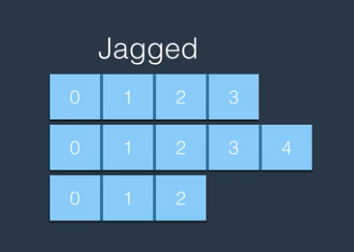

This we can view as array of arrays...So first item of first line, can be an single dim of array of 4 elements, and the second item (of second line), can be another single array of 5 elements, and so forth.

We implement it by declaring a top level array, where the 3 refers to the 3 rows (which will contain 3 arrays in it)

```
var arrTop = new int[3][];
```

Also compared to the rectangualr array, we use two square brackets.

Next we need to initialize the rest

```
arrTop[0] = new int[4]; //first row
arrTop[1] = new int[5]; //second row
arrTop[2] = new int[3]; //third row
```

And to access element, we use 2 square brackets

```
arrTop[0][0]=1;
```

So here we working with Array class in CLR, where we can use the static fields and methods.

```csharp
//Keeping the code ven shorted, we dont even need to specify new int[], can just say new[]
var numbers = new[]{3,7,9,2,14,6};
Console.WriteLine("The size of the array is {0}", numbers.Length);
```

```
The size of the array is 6
```

```csharp
//Play wit Array class annd it static fields/members and methods

var arrIndPos = Array.IndexOf(numbers, 3);
Console.WriteLine("The position of element at 3 is {0}", arrIndPos);
```

```
The position of element at 3 is 0
```

## List

Remember arrays have a fixed size. So they cannot be changed at runtime. Lists are similar to arrays, but we do not have to specify the size.

We create list as follows:

```
var numbers = new List<int>();
```

1. var keyword, remember this is shortcut for data type that needs to be specified here.
2. Then Specifythe variable
3. Then allocate memory with new keyword
4. Bur before we specify the data type, we use the List Class, then the type, but within greater/less than symbols, followed by parenthesis

Remember List is a generic, thats why its followed by `<type>` syntax

So in the above example we creating a list of integers (primitive types). Can also create a list of non-primitive types.

```
List<Products>
```

Where Products is a class.

Can also initialize the object just like an array: {2,3,4,5,7}

And we have the following methods:

```
Add()
AddRange()
Remove
ect....
```

```csharp
var numbers = new List<int>(){5,72,34,45,6,9};
numbers.Add(67);

//can fill with anther list or array
numbers.AddRange(new int[3]{1,2,3});

foreach(var nums in numbers){
    Console.WriteLine(nums);
}
```

```
5
72
34
45
6
9
67
1
2
3
```